# Penambangan Data D

[figure not shown]

# **Membuat Akun Aiven**

Buat akun Aiven terlebih dahulu di aiven io dan Selanjutnya create project minimal 2. Untuk Menjadi Database Mysql dan PostreSQL.

# **Sambungkan dengan DBaver**

Sambungkan ke Aiven dengan membuat database baru. Hubungkan menggunakan username, password, nama database, port, dan host yang telah diberikan. Setelah berhasil terhubung, untuk MySQL, buat tabel terlebih dahulu sebelum mengimpor data. Sementara itu, untuk PostgreSQL, tabel tidak perlu dibuat secara manual karena data dapat langsung diimpor.

```python
!pip install pymysql psycopg2 pandas sqlalchemy
```

```
     ━━━━━━━━━━━━━━━━━━━━━━━━━━━━━━━━━━━━━━━━ 0.0/45.0 kB ? eta -:--:--
     ━━━━━━━━━━━━━━━━━━━━━━━━━━━━━━━━━━━━━━━━ 45.0/45.0 kB 3.0 MB/s eta 0:00:00
```

Penjelasan masing-masing pustaka:

pymysql → Driver untuk menghubungkan Python dengan database MySQL.

psycopg2 → Driver untuk menghubungkan Python dengan database PostgreSQL.

pandas → Digunakan untuk memproses, mengelola, dan menganalisis data dalam bentuk tabel (DataFrame).

sqlalchemy → Library ORM (Object-Relational Mapping) untuk mengelola koneksi ke database dengan cara yang lebih fleksibel dan terstruktur.

# **Koneksi dan menggabungkan**

```python
import pandas as pd
  from sqlalchemy import create_engine

  # Koneksi ke MySQL
  mysql_user = "avnadmin"
  mysql_password = "mypassword"
  mysql_host = "mysql-3c9d955a-rohmanfake26-e80f.i.aivencloud.com"
  mysql_port = "13231"
  mysql_db = "defaultdb"

  mysql_engine = create_engine(f"mysql+pymysql://{mysql_user}:{mysql_password}@{mysql_host}:{mysql_port}/{mysql_db}")

  # Koneksi ke PostgreSQL
  pg_user = "avnadmin"
  pg_password = "mypassword"
  pg_host = "pg-16046fad-iriissql.i.aivencloud.com"
  pg_port = "13780"
  pg_db = "defaultdb"

  pg_engine = create_engine(f"postgresql+psycopg2://{pg_user}:{pg_password}@{pg_host}:{pg_port}/{pg_db}")

  # Ambil data dari MySQL
  query_mysql = 'SELECT id, "Class", petal_length, petal_width FROM iris'
  df_mysql = pd.read_sql(query_mysql, mysql_engine)

  # Ambil data dari PostgreSQL
  query_pg = 'SELECT id, "Class", sepal_length, sepal_width FROM irispostgres'
  df_pg = pd.read_sql(query_pg, pg_engine)

  # Gabungkan berdasarkan id dan Class (full outer join untuk menjaga semua data)
  df_combined = pd.merge(df_mysql, df_pg, on=["id", "Class"], how="outer")

  # Simpan ke CSV tanpa mengubah nilai NaN
  df_combined.to_csv("combined_iris.csv", index=False)

  # Print hasil gabungan tanpa indeks tambahan
  print(df_combined.to_string(index=False))
```

```
 id           Class  petal_length  petal_width  sepal_length  sepal_width
    1     Iris-setosa           1.4          0.2           5.1          3.5
    2     Iris-setosa           1.4          0.2           4.9          3.0
    3     Iris-setosa           1.3          0.2           4.7          3.2
    4     Iris-setosa           1.5          0.2           4.6          3.1
    5     Iris-setosa           1.4          0.2           5.0          3.6
    6     Iris-setosa           1.7          0.4           5.4          3.9
    7     Iris-setosa           1.4          0.3           4.6          3.4
    8     Iris-setosa           1.5          0.2           5.0          3.4
    9     Iris-setosa           1.4          0.2           4.4          2.9
   10     Iris-setosa           1.5          0.1           4.9          3.1
   11     Iris-setosa           1.5          0.2           5.4          3.7
   12     Iris-setosa           1.6          0.2           4.8          3.4
   13     Iris-setosa           1.4          0.1           4.8          3.0
   14     Iris-setosa           1.1          0.1           4.3          3.0
```

[output cut: 136 more lines]

# **Fitur Data Table**

```python
# Tambahkan styling untuk tampilan tabel lebih rapi
  styled_df = df_combined.style.set_properties(**{
      'border': '1px solid black',
      'color': 'black',
      'background-color': 'white'
  }).set_table_styles([
      {'selector': 'th', 'props': [('background-color', '#FFA500'), ('color', 'black'), ('font-weight', 'bold')]}
  ])

  # Menampilkan DataFrame dengan styling
  display(styled_df)
```

|  | id | Class | petal_length | petal_width | sepal_length | sepal_width |
| --- | --- | --- | --- | --- | --- | --- |
| 0 | 1 | Iris-setosa | 1.400000 | 0.200000 | 5.100000 | 3.500000 |
| 1 | 2 | Iris-setosa | 1.400000 | 0.200000 | 4.900000 | 3.000000 |
| 2 | 3 | Iris-setosa | 1.300000 | 0.200000 | 4.700000 | 3.200000 |
| 3 | 4 | Iris-setosa | 1.500000 | 0.200000 | 4.600000 | 3.100000 |
| 4 | 5 | Iris-setosa | 1.400000 | 0.200000 | 5.000000 | 3.600000 |
| 5 | 6 | Iris-setosa | 1.700000 | 0.400000 | 5.400000 | 3.900000 |
| 6 | 7 | Iris-setosa | 1.400000 | 0.300000 | 4.600000 | 3.400000 |
| 7 | 8 | Iris-setosa | 1.500000 | 0.200000 | 5.000000 | 3.400000 |
| 8 | 9 | Iris-setosa | 1.400000 | 0.200000 | 4.400000 | 2.900000 |
| 9 | 10 | Iris-setosa | 1.500000 | 0.100000 | 4.900000 | 3.100000 |
| 10 | 11 | Iris-setosa | 1.500000 | 0.200000 | 5.400000 | 3.700000 |
| 11 | 12 | Iris-setosa | 1.600000 | 0.200000 | 4.800000 | 3.400000 |
| 12 | 13 | Iris-setosa | 1.400000 | 0.100000 | 4.800000 | 3.000000 |
| 13 | 14 | Iris-setosa | 1.100000 | 0.100000 | 4.300000 | 3.000000 |
| 14 | 15 | Iris-setosa | 1.200000 | 0.200000 | 5.800000 | 4.000000 |
| 15 | 16 | Iris-setosa | 1.500000 | 0.400000 | 5.700000 | 4.400000 |
| 16 | 17 | Iris-setosa | 1.300000 | 0.400000 | 5.400000 | 3.900000 |
| 17 | 18 | Iris-setosa | 1.400000 | 0.300000 | 5.100000 | 3.500000 |
| 18 | 19 | Iris-setosa | 1.700000 | 0.300000 | 5.700000 | 3.800000 |
| 19 | 20 | Iris-setosa | 1.500000 | 0.300000 | 5.100000 | 3.800000 |
| 20 | 21 | Iris-setosa | 1.700000 | 0.200000 | 5.400000 | 3.400000 |
| 21 | 22 | Iris-setosa | 1.500000 | 0.400000 | 5.100000 | 3.700000 |
| 22 | 23 | Iris-setosa | 1.000000 | 0.200000 | 4.600000 | 3.600000 |
| 23 | 24 | Iris-setosa | 1.700000 | 0.500000 | 5.100000 | 3.300000 |
| 24 | 25 | Iris-setosa | 1.900000 | 0.200000 | 4.800000 | 3.400000 |
| 25 | 26 | Iris-setosa | 1.600000 | 0.200000 | 5.000000 | 3.000000 |
| 26 | 27 | Iris-setosa | 1.600000 | 0.400000 | 5.000000 | 3.400000 |
| 27 | 28 | Iris-setosa | 1.500000 | 0.200000 | 5.200000 | 3.500000 |
| 28 | 29 | Iris-setosa | 1.400000 | 0.200000 | 5.200000 | 3.400000 |
| 29 | 30 | Iris-setosa | 1.600000 | 0.200000 | 4.700000 | 3.200000 |

[output cut: 120 more lines]

```python
from google.colab import data_table

  # Menampilkan dataframe tanpa indeks tambahan
  data_table.DataTable(df_combined, include_index=False)
```

|  | id | Class | petal_length | petal_width | sepal_length | sepal_width |
| --- | --- | --- | --- | --- | --- | --- |
| 0 | 1 | Iris-setosa | 1.4 | 0.2 | 5.1 | 3.5 |
| 1 | 2 | Iris-setosa | 1.4 | 0.2 | 4.9 | 3.0 |
| 2 | 3 | Iris-setosa | 1.3 | 0.2 | 4.7 | 3.2 |
| 3 | 4 | Iris-setosa | 1.5 | 0.2 | 4.6 | 3.1 |
| 4 | 5 | Iris-setosa | 1.4 | 0.2 | 5.0 | 3.6 |
| 5 | 6 | Iris-setosa | 1.7 | 0.4 | 5.4 | 3.9 |
| 6 | 7 | Iris-setosa | 1.4 | 0.3 | 4.6 | 3.4 |
| 7 | 8 | Iris-setosa | 1.5 | 0.2 | 5.0 | 3.4 |
| 8 | 9 | Iris-setosa | 1.4 | 0.2 | 4.4 | 2.9 |
| 9 | 10 | Iris-setosa | 1.5 | 0.1 | 4.9 | 3.1 |
| 10 | 11 | Iris-setosa | 1.5 | 0.2 | 5.4 | 3.7 |
| 11 | 12 | Iris-setosa | 1.6 | 0.2 | 4.8 | 3.4 |
| 12 | 13 | Iris-setosa | 1.4 | 0.1 | 4.8 | 3.0 |
| 13 | 14 | Iris-setosa | 1.1 | 0.1 | 4.3 | 3.0 |
| 14 | 15 | Iris-setosa | 1.2 | 0.2 | 5.8 | 4.0 |
| 15 | 16 | Iris-setosa | 1.5 | 0.4 | 5.7 | 4.4 |
| 16 | 17 | Iris-setosa | 1.3 | 0.4 | 5.4 | 3.9 |
| 17 | 18 | Iris-setosa | 1.4 | 0.3 | 5.1 | 3.5 |
| 18 | 19 | Iris-setosa | 1.7 | 0.3 | 5.7 | 3.8 |
| 19 | 20 | Iris-setosa | 1.5 | 0.3 | 5.1 | 3.8 |
| 20 | 21 | Iris-setosa | 1.7 | 0.2 | 5.4 | 3.4 |
| 21 | 22 | Iris-setosa | 1.5 | 0.4 | 5.1 | 3.7 |
| 22 | 23 | Iris-setosa | 1.0 | 0.2 | 4.6 | 3.6 |
| 23 | 24 | Iris-setosa | 1.7 | 0.5 | 5.1 | 3.3 |
| 24 | 25 | Iris-setosa | 1.9 | 0.2 | 4.8 | 3.4 |
| 25 | 26 | Iris-setosa | 1.6 | 0.2 | 5.0 | 3.0 |
| 26 | 27 | Iris-setosa | 1.6 | 0.4 | 5.0 | 3.4 |
| 27 | 28 | Iris-setosa | 1.5 | 0.2 | 5.2 | 3.5 |
| 28 | 29 | Iris-setosa | 1.4 | 0.2 | 5.2 | 3.4 |
| 29 | 30 | Iris-setosa | 1.6 | 0.2 | 4.7 | 3.2 |

[output cut: 120 more lines]

# **Menampilkan dan Mendownload Data**

```python
# Gabungkan berdasarkan id dan Class (full outer join untuk menjaga semua data)
  df_combined = pd.merge(df_mysql, df_pg, on=["id", "Class"], how="outer")

  # Simpan ke CSV tanpa mengubah nilai NaN
  df_combined.to_csv("combined_iris.csv", index=False)

  # Print hasil gabungan tanpa indeks tambahan
  print(df_combined.to_string(index=False))

  # Unduh file CSV di Google Colab
  files.download("combined_iris.csv")
```

```
 id           Class  petal_length  petal_width  sepal_length  sepal_width
    1     Iris-setosa           1.4          0.2           5.1          3.5
    2     Iris-setosa           1.4          0.2           4.9          3.0
    3     Iris-setosa           1.3          0.2           4.7          3.2
    4     Iris-setosa           1.5          0.2           4.6          3.1
    5     Iris-setosa           1.4          0.2           5.0          3.6
    6     Iris-setosa           1.7          0.4           5.4          3.9
    7     Iris-setosa           1.4          0.3           4.6          3.4
    8     Iris-setosa           1.5          0.2           5.0          3.4
    9     Iris-setosa           1.4          0.2           4.4          2.9
   10     Iris-setosa           1.5          0.1           4.9          3.1
   11     Iris-setosa           1.5          0.2           5.4          3.7
   12     Iris-setosa           1.6          0.2           4.8          3.4
   13     Iris-setosa           1.4          0.1           4.8          3.0
   14     Iris-setosa           1.1          0.1           4.3          3.0
```

[output cut: 136 more lines]

# **Fitur Pivot Table**

```python
# Buat Pivot Table: Count & Sum berdasarkan Class dan ID
  pivot_table = df_combined.pivot_table(
      index="Class",
      values="id",
      aggfunc=["count", "sum"],
      margins=True,
      margins_name="Total"
  )

  # Ubah nama kolom agar sesuai dengan Orange
  pivot_table.columns = ["Count", "Sum"]

  # Simpan Pivot Table ke CSV
  pivot_table.to_csv("pivot_iris_orange.csv")

  # Print hasil Pivot Table
  print(pivot_table.to_string())
```

```
                 Count    Sum
  Class
  Iris-setosa         50   1275
  Iris-versicolor     50   3775
  Iris-virginica      50   6275
  Total              150  11325
```

Kode ini adalah bagian dari Eksplorasi Data (EDA) dalam Data Science, yang digunakan untuk:

Membaca dan memahami struktur dataset.

Menghitung statistik dasar untuk memahami sebaran data.

Melihat distribusi data melalui visualisasi.

Mendeteksi adanya outlier atau missing values.

```
=== Statistik Data Numerik ===
                     Mean  Median  Mode  Standard Deviation     Variance  Min    Max  Missing Values
  id            75.500000   75.50   1.0           43.445368  1887.500000  1.0  150.0               0
  petal_length   3.758667    4.35   1.5            1.764420     3.113179  1.0    6.9               0
  petal_width    1.198667    1.30   0.2            0.763161     0.582414  0.1    2.5               0
  sepal_length   5.843333    5.80   5.0            0.828066     0.685694  4.3    7.9               0
  sepal_width    3.054000    3.00   3.0            0.433594     0.188004  2.0    4.4               0

  === Distribusi Class ===
  Class
  Iris-setosa        50
  Iris-versicolor    50
  Iris-virginica     50
  Name: count, dtype: int64
```

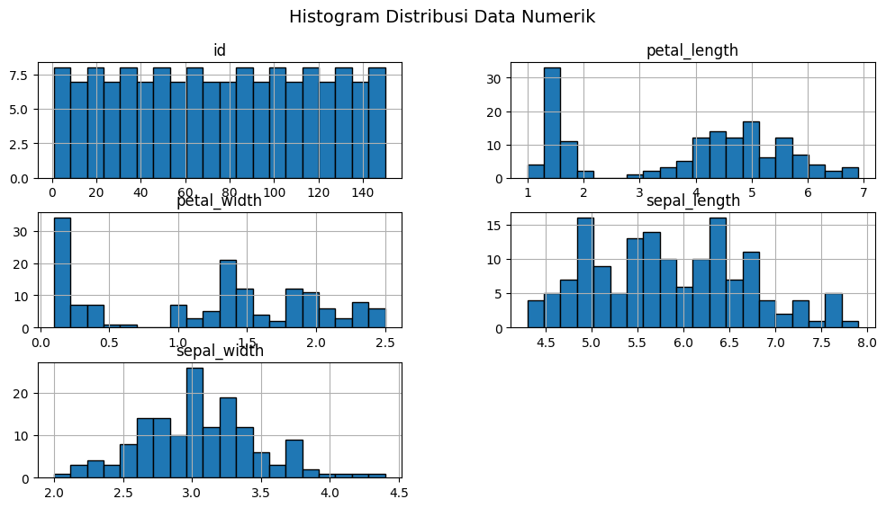

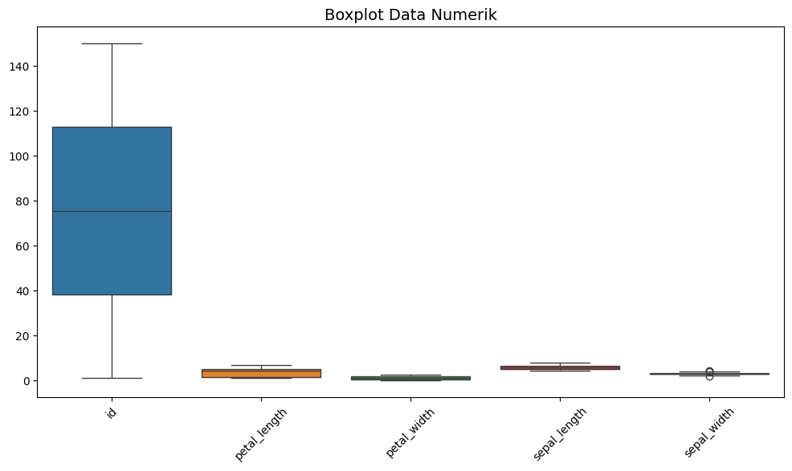

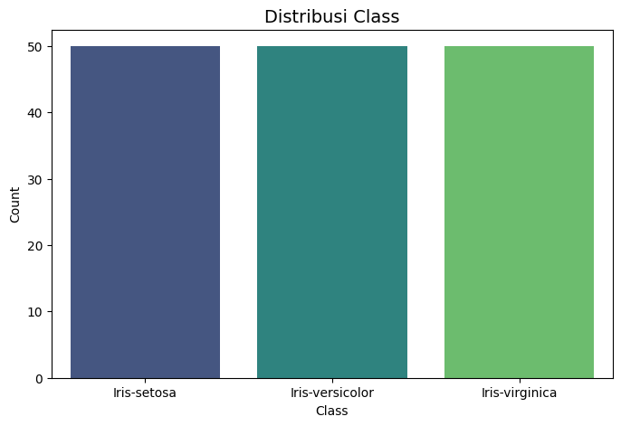

```python
import pandas as pd
  import matplotlib.pyplot as plt
  import seaborn as sns

  # Baca data gabungan dari file CSV yang telah digabung sebelumnya
  df_combined = pd.read_csv("combined_iris.csv")

  # Pisahkan kolom numerik dan non-numerik
  numeric_columns = df_combined.select_dtypes(include=["number"])
  non_numeric_columns = df_combined.select_dtypes(exclude=["number"])

  # Hitung berbagai statistik deskriptif
  feature_stats = pd.DataFrame()

  feature_stats["Mean"] = numeric_columns.mean()
  feature_stats["Median"] = numeric_columns.median()
  feature_stats["Mode"] = numeric_columns.mode().iloc[0]  # Mode bisa lebih dari satu nilai, ambil yang pertama
  feature_stats["Standard Deviation"] = numeric_columns.std()
  feature_stats["Variance"] = numeric_columns.var()
  feature_stats["Min"] = numeric_columns.min()
  feature_stats["Max"] = numeric_columns.max()
  feature_stats["Missing Values"] = numeric_columns.isnull().sum()

  # Print hasil statistik
  print("=== Statistik Data Numerik ===")
  print(feature_stats.to_string())

  # Statistik untuk kolom Class
  class_counts = df_combined["Class"].value_counts()
  print("\n=== Distribusi Class ===")
  print(class_counts)

  # ====== GRAFIK VISUALISASI ======

  # 1. Histogram untuk distribusi data numerik
  plt.figure(figsize=(12, 6))
  numeric_columns.hist(figsize=(12, 6), bins=20, edgecolor='black')
  plt.suptitle("Histogram Distribusi Data Numerik", fontsize=14)
  plt.show()

  # 2. Boxplot untuk melihat outlier
  plt.figure(figsize=(12, 6))
  sns.boxplot(data=numeric_columns)
  plt.title("Boxplot Data Numerik", fontsize=14)
  plt.xticks(rotation=45)
  plt.show()

  # 3. Barplot untuk distribusi class
  plt.figure(figsize=(8, 5))
  sns.barplot(x=class_counts.index, y=class_counts.values, palette="viridis")
  plt.title("Distribusi Class", fontsize=14)
  plt.xlabel("Class")
  plt.ylabel("Count")
  plt.show()
```